# Factor Analysis

Bert Gollnick

```r
library(dplyr)
library(tidyr)
library(ggplot2)
library(knitr)
library(psych)
library(corrplot)
library(GPArotation)
library(reshape2)
library(gridExtra)
```

# 1 Introduction

Exploratory factor analysis is performed to find a lower number of unobserved variables (factors) in a larger number of correlated variables. It is a statistical technique for dimension reduction. We will analyse “forest fires” dataset.

# 2 Data Preparation and -understanding

This dataset is usually used for prediction of forest fires based on meteorological data. We will use it to see which variables are related and might be driven by unobservable factors.

## 2.1 Data Import

```r
file_name <- "./data/fires.csv"
if (!file.exists(file_name)) {
  url <- "https://archive.ics.uci.edu/ml/machine-learning-databases/forest-fires/forestfires.csv"
  download.file(url = url, destfile = file_name)
}

fires <- read.csv(file = file_name)
```

## 2.2 Data Manipulation

```r
fires <- fires %>%
  dplyr::select(-month, -day)
```

## 2.3 Data Understanding

```r
fires %>% head() %>% kable()
```

| X | Y | FFMC | DMC | DC | ISI | temp | RH | wind | rain | area |
| --- | --- | --- | --- | --- | --- | --- | --- | --- | --- | --- |
| 7 | 5 | 86.2 | 26.2 | 94.3 | 5.1 | 8.2 | 51 | 6.7 | 0.0 | 0 |
| 7 | 4 | 90.6 | 35.4 | 669.1 | 6.7 | 18.0 | 33 | 0.9 | 0.0 | 0 |
| 7 | 4 | 90.6 | 43.7 | 686.9 | 6.7 | 14.6 | 33 | 1.3 | 0.0 | 0 |
| 8 | 6 | 91.7 | 33.3 | 77.5 | 9.0 | 8.3 | 97 | 4.0 | 0.2 | 0 |
| 8 | 6 | 89.3 | 51.3 | 102.2 | 9.6 | 11.4 | 99 | 1.8 | 0.0 | 0 |
| 8 | 6 | 92.3 | 85.3 | 488.0 | 14.7 | 22.2 | 29 | 5.4 | 0.0 | 0 |

Some variables might require some explanation. Some FWI (Fire Weather Index) variables are used.

- FFMC: Fine Fuel Moisture Code – moisture content of surface litter
- DMC: Duff Moisture Code – rating for average moisture content of loosely connected organic layers
- DC: Drought Code – moisture content of deep, compact, organic layers
- ISI: Initial Spread Index – rate of fire spreading at its beginning

Which of these variables are relevant?

## 2.4 Relevant Variables

Kaiser-Meyer-Olkin (KMO) test can be performed to answer this question. Function KMO() from psych package checks if a variable is suitable for factor analysis.

```r
fires_corr <- cor(fires)
KMO(fires_corr)
```

```
## Kaiser-Meyer-Olkin factor adequacy
## Call: KMO(r = fires_corr)
## Overall MSA =  0.61
## MSA for each item =
##    X    Y FFMC  DMC   DC  ISI temp   RH wind rain area
## 0.51 0.49 0.72 0.63 0.72 0.64 0.63 0.40 0.49 0.39 0.69
```

MSA (measure of sampling adequacy) is a measure for exclusion of variables. If MSA < 0.5 the variable should be dropped. Variables with MSA > 0.6 are suitable, variables with MSA > 0.8 very well suited for factor analysis.

With residual variables we calculate correlation matrix with cor().

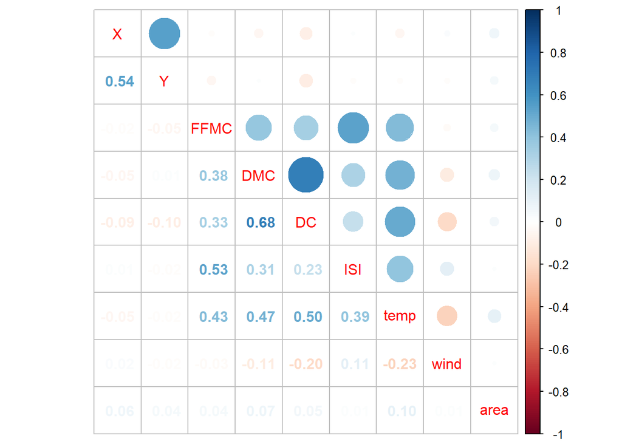

```r
fires$month <- NULL
fires$RH <- NULL
fires$rain <- NULL
fires_corr <- cor(fires)
round(fires_corr, 2) %>% corrplot.mixed()
```

# 3 Factor Analysis

We perform factor analysis. At this stage we don’t know how many factors should be used. We will start with three. We can check our assumption at a later stage. Factor analysis will be performed with fa() function from psych package. As parameters are passed: a correlation matrix, the number of factors, and a rotation. The last parameter can increase factor loadings, but don’t have an impact on the result, if rotation is orthogonal. If rotation is oblique, factors themselfes are correlated. “Oblimin” is an oblique rotation.

```r
nfactors <- 3
nvariables <- dim(fires_corr)[1]
factors <- fa(r = fires_corr, nfactors = nfactors, rotate = "oblimin")
```

## 3.1 Eigenvalues and Explained Variance

We will create a Scree-plot. It shows Eigenvalues and cumulated explained variance as a function of number of factors. The red line represents Kaiser-criterion, which means that the number of factors should be chosen so that Eigenvalues are above one.

For visualisation I use gplot2 package. We create a dataframe “eigenvalues” based on variable “e.values” within “factors” variable.

Explained variance is calculated with ratio of cumulated Eigenvalues to total sum of Eigenvalues.

Plot is stored in “e1” variable.

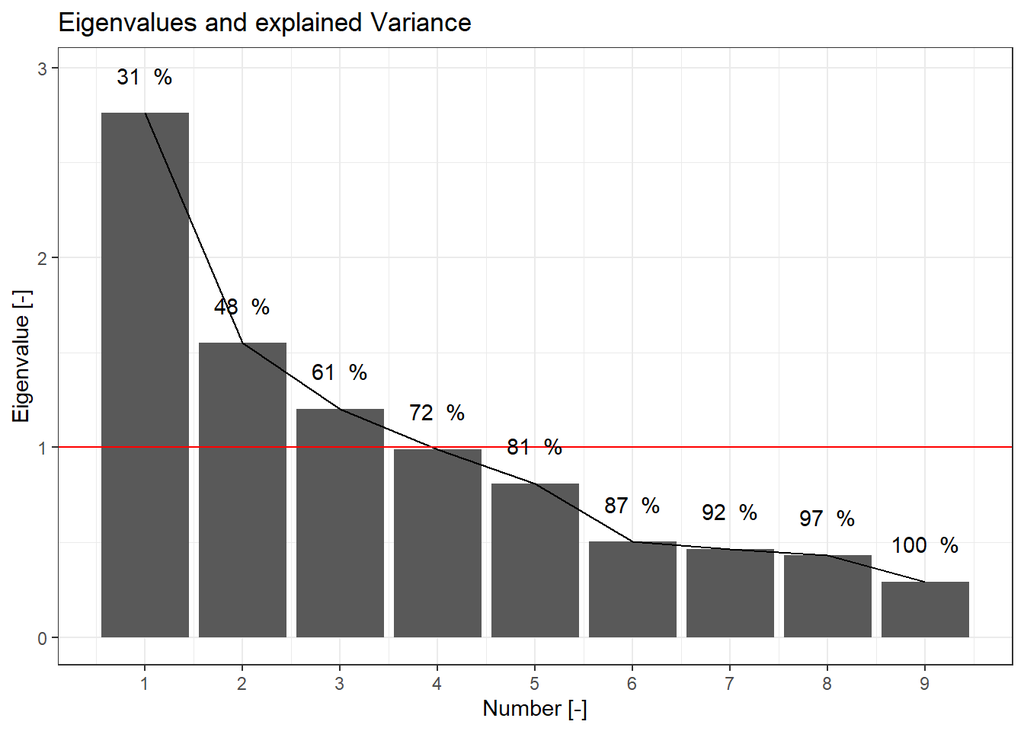

```r
eigenvalues <- data.frame(factors$e.values)
colnames(eigenvalues) <- c("Values")
eigenvalues$Number <- 1:nrow(fires_corr)

eigenvalues$RepresentedVariance <- NA
for (i in 1:nrow(fires_corr)) {
    eigenvalues$RepresentedVariance[i] <- sum(eigenvalues$Values[1:i])/sum(eigenvalues$Values) *
        100
}
eigenvalues$RepresentedVariance_text <- paste(round(eigenvalues$RepresentedVariance,
    0), " %")

e1 <- ggplot(eigenvalues, aes(Number, y = Values), group = 1)
e1 <- e1 + geom_bar(stat = "identity")
e1 <- e1 + geom_line(aes(y = Values), group = 2)
e1 <- e1 + xlab("Number [-]")
e1 <- e1 + ylab("Eigenvalue [-]")
e1 <- e1 + geom_hline(aes(yintercept = 1), col = "red")
e1 <- e1 + geom_text(aes(label = RepresentedVariance_text), nudge_y = 0.2)
e1 <- e1 + ggtitle("Eigenvalues and explained Variance")
e1 <- e1 + theme_bw()
e1 <- e1 + scale_x_continuous(breaks = seq(1, 10, 1))
e1
```

In our case it is a tough decision. Three factors is definitely a possible solution. Four our five are also arguable. I decide to use three factors.

The number of factors might also be chosen based on a number of other criteria or even defined by the user based on model knowledge.

## 3.2 Factor Loadings: Factor 1 vs. Factor 2

We will create a plot that shows factor loadings for factor 1 and factor 2 for all variables. We load dplyr and tidyr package.

A loadings matrix template is created with as many rows as variables and as many columns as factors. Loadings are stored in “factors$loadings”. With nested for-loops loadings are extracted and stored in loadings matrix.

Finally, column names are defined and dataframe is reshaped to be suitable for ggplot.

```r
loadings_mat <- as.data.frame(matrix(nrow = nvariables, ncol =nfactors))
loadings_mat$Variable <- colnames(fires)
for (i in 1:nfactors) {
  for (j in 1:nvariables) {
    loadings_mat[j, i] <- factors$loadings[j, i]
  }
}
colnames(loadings_mat) <- c("Factor1", "Factor2", "Factor3", "Variable")
loadings_mat_gather <- loadings_mat %>% gather("Factor", "Value", 1:nfactors)
```

Now we create the plot.

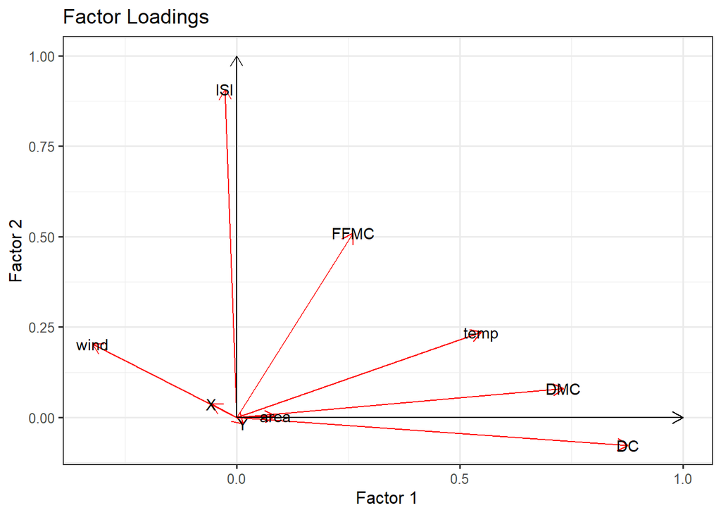

```r
loadings_mat$Zero <- 0
f1 <- ggplot(loadings_mat, aes(Zero, Zero))
f1 <- f1 + geom_segment(aes(xend = Factor1, yend=Factor2),
                        arrow = arrow(length = unit(0.3,"cm")), col="red")  # Variables
f1 <- f1 + geom_text(aes(x = Factor1, y = Factor2, label = Variable))  # Labels
f1 <- f1 + geom_segment(aes(xend = 1, yend=0),
                        arrow = arrow(length = unit(0.3,"cm")), col="black")  # X-Axis
f1 <- f1 + geom_segment(aes(xend = 0, yend=1),
                        arrow = arrow(length = unit(0.3,"cm")), col="black")  # X-Axis
f1 <- f1 + xlab("Factor 1")
f1 <- f1 + ylab("Factor 2")
f1 <- f1 + ggtitle("Factor Loadings")
f1 <- f1 + theme_bw(base_size=12)
f1 <- f1 + theme(legend.position="none")
f1
```

## 3.3 Factors Loadings: Factors and Variables

I won’t go into detail on how this graph is created. We will focus on its meaning.

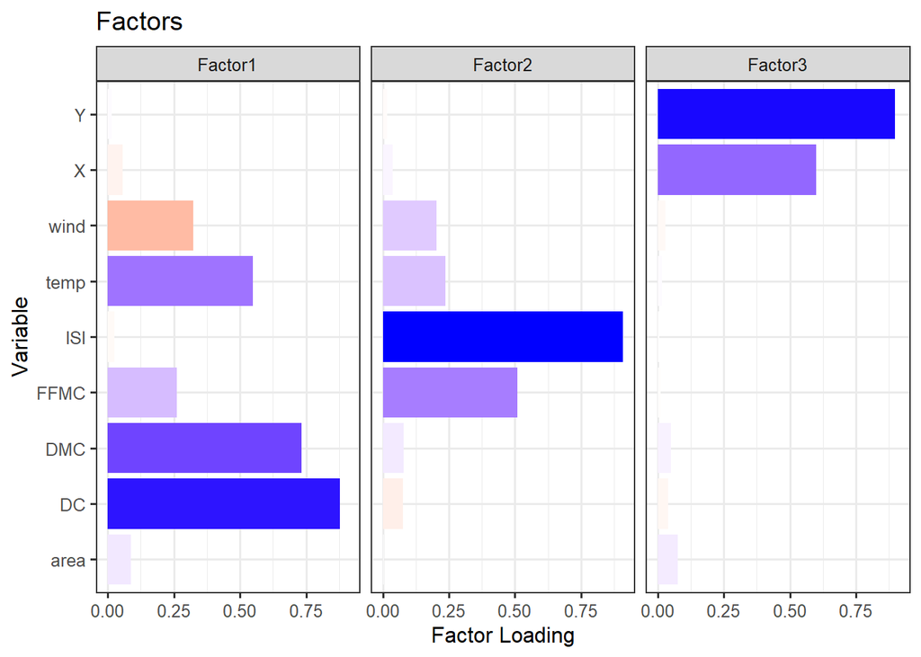

```r
g1 <- ggplot(loadings_mat_gather, aes(Variable, abs(Value), fill=Value))
g1 <- g1 + facet_wrap(~ Factor, nrow=1)
g1 <- g1 +geom_bar(stat="identity")
g1 <- g1 + coord_flip()
g1 <- g1 + scale_fill_gradient2(name = "Loading",
                       high = "blue", mid = "white", low = "red",
                       midpoint=0, guide=F)
g1 <- g1 + xlab("Variable")  # improve x-axis label
g1 <- g1 + ylab("Factor Loading")  #improve y-axis label
g1 <- g1 + ggtitle("Factors")
g1 <- g1 + theme(axis.text=element_text(size=12),
        axis.title=element_text(size=12, face="bold"))
g1 <- g1 + theme(plot.title = element_text(size=12))
g1 <- g1 + theme_bw(base_size=12)
g1
```

You see factor loadings for all three factors and each variable.

## 3.4 Correlation Matrix and Factor Loadings

We will need packages reshape2 and gridExtra.

At the end we will show two plots: a reduced correlation matrix and factor loadings.

We create a reduced correlation matrix. It has at its diagonal communalities, which are extracted from “factors$communality”. With melt() function from reshape2 package it is brought into a shape to work smoothly with ggplot().

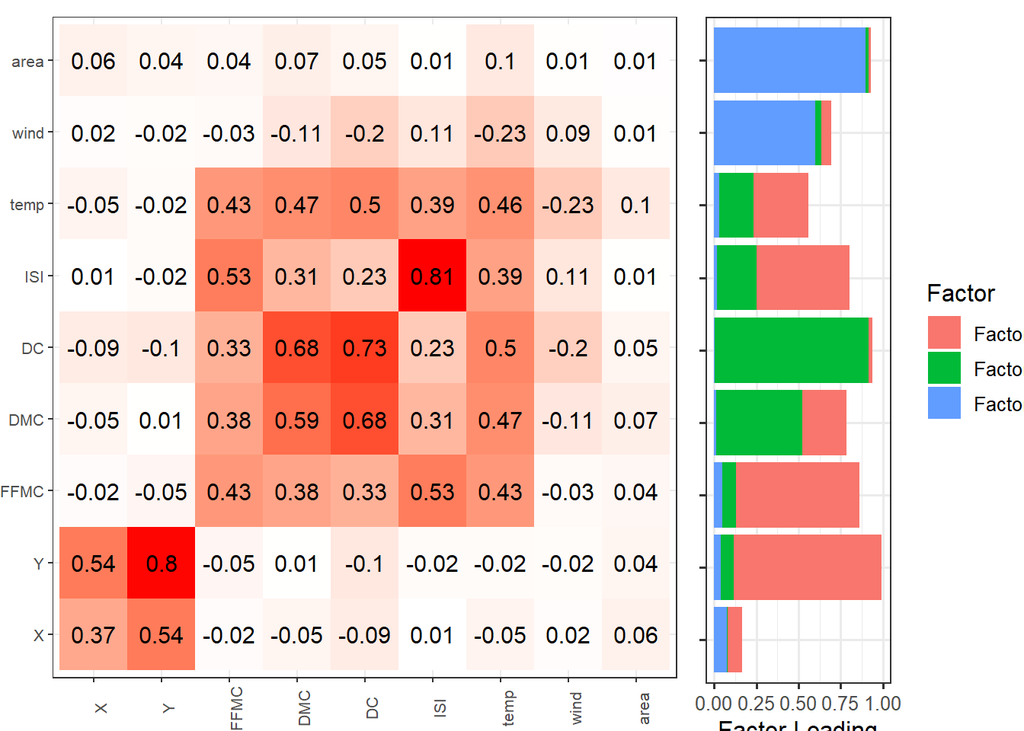

```r
corr_reduced <- fires_corr
for (i in 1: nvariables) {
  corr_reduced[i, i] <- factors$communality[i]
}

corr_melt <- corr_reduced %>% melt()
corr_melt <- corr_melt[order(corr_melt$Var2), ]
p1 <- ggplot(corr_melt, aes(Var1, Var2, fill=abs(value)))
p1 <- p1 + geom_tile()  #rectangles for each correlation
p1 <- p1 + geom_text(aes(label = round(value, 2)), size=4)
  #add actual correlation value in the rectangle
p1 <- p1 + theme_bw(base_size=10)  #black and white theme with set font size
  #rotate x-axis labels so they don't overlap,
  #get rid of unnecessary axis titles
  #adjust plot margins
p1 <- p1 + theme(axis.text.x = element_text(angle = 90),
        axis.title.x=element_blank(),
        axis.title.y=element_blank(),
        plot.margin = unit(c(3, 1, 0, 0), "mm"))
  #set correlation fill gradient
p1 <- p1 + scale_fill_gradient(low="white", high="red") + guides(fill=F)
  #omit unnecessary gradient legend

p2 <- ggplot(loadings_mat_gather, aes(Variable, abs(Value), fill=Factor))
p2 <- p2 + geom_bar(stat="identity") + coord_flip()
p2 <- p2 + ylab("Factor Loading")
p2 <- p2 + theme_bw(base_size=12)
#remove labels and tweak margins for combining with the correlation matrix plot
p2 <- p2 +theme(axis.text.y = element_blank(),
        axis.title.y = element_blank(),
        plot.margin = unit(c(3, -5, -2, 3), "mm"))
grid.arrange(p1, p2, ncol=2, widths=c(2, 1)) #side-by-side, matrix gets more space
```